# Machine Learning (ML) Bioinformatics Workshop – Hands-on application of ML on drug response prediction data using R

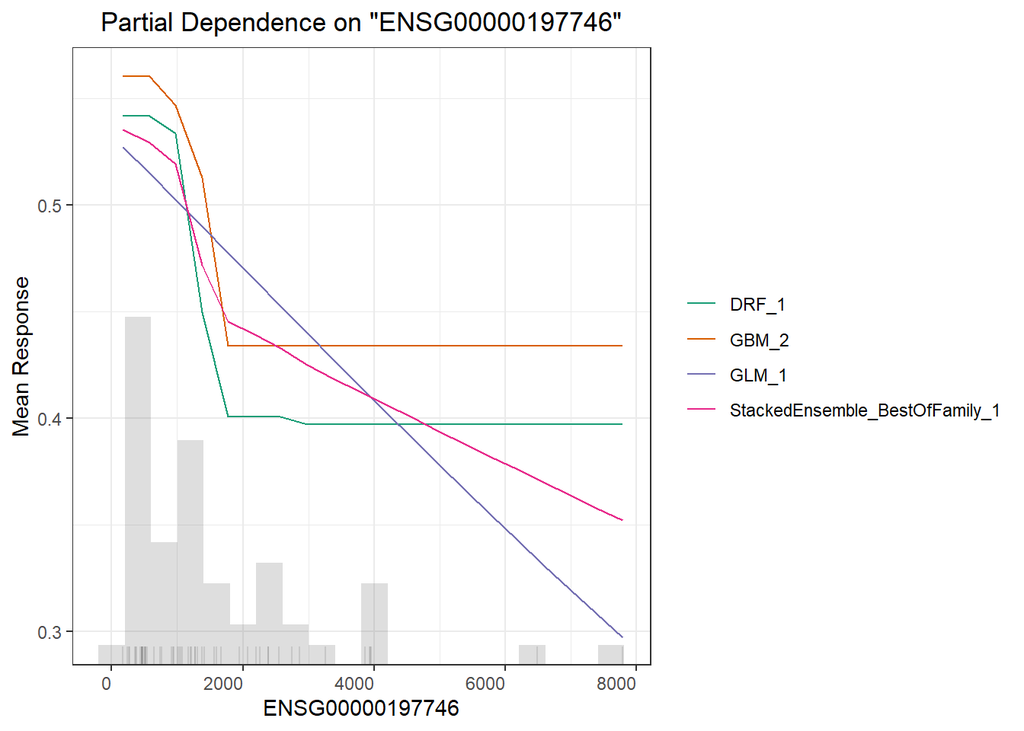

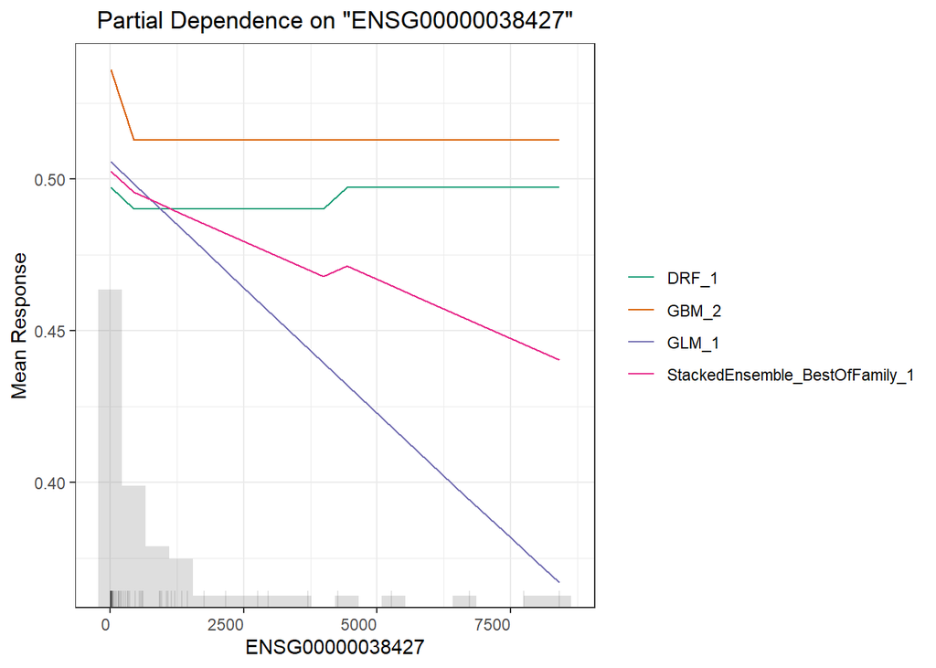

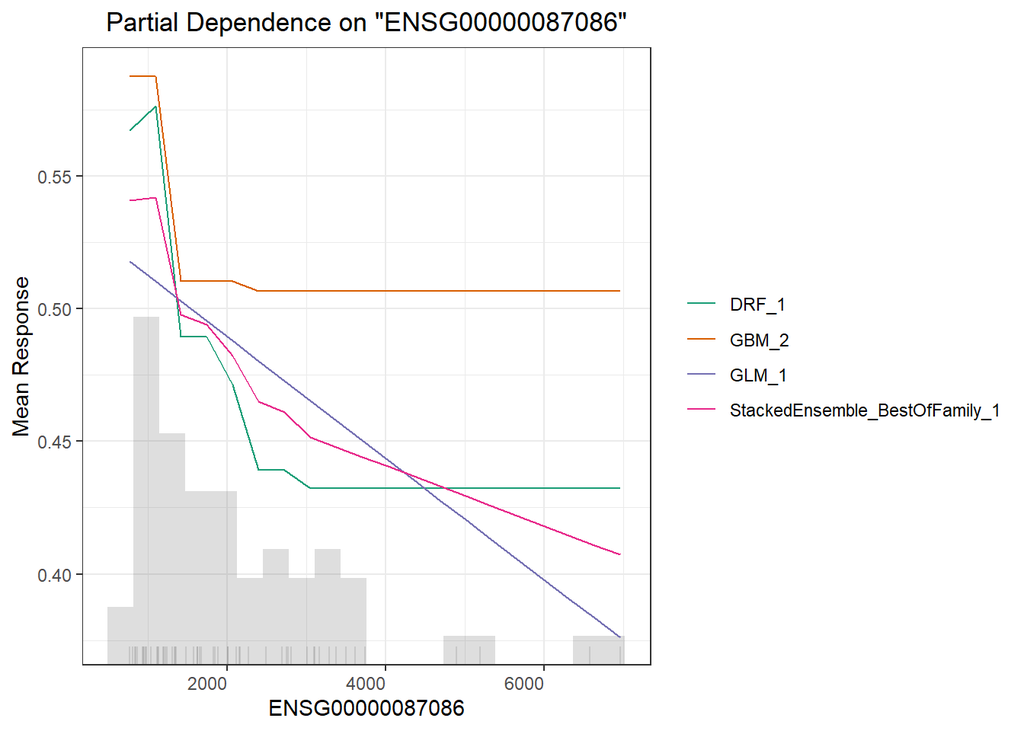

Explain a single H2O model (e.g. leader model from AutoML)

```r
# Get the leaderboard
lb <- aml@leaderboard

# Get the ID of the second model
second_model_id <- as.data.frame(lb$model_id)[2, 1]

# Retrieve the model
model2explain <- h2o.getModel(second_model_id)

# Explain the model
exm <- h2o.explain(model2explain, test_h2o)
exm
```

```
##
##
## Confusion Matrix
## ================
##
## > Confusion matrix shows a predicted class vs an actual class.
##
##
##
## DRF_1_AutoML_1_20250430_170242
## ------------------------------
##
## |  | Resistant | Sensitive | Error | Rate
## |:---:|:---:|:---:|:---:|:---:|
## | **Resistant** |19 | 9 | 0.321428571428571 |  =9/28 |
## | **Sensitive** |1 | 26 | 0.037037037037037 |  =1/27 |
## | **Totals** |20 | 35 | 0.181818181818182 |  =10/55 |
##
##
## Learning Curve Plot
## ===================
##
## > Learning curve plot shows the loss function/metric dependent on number of iterations or trees for tree-based algorithms. This plot can be useful for determining whether the model overfits.
```

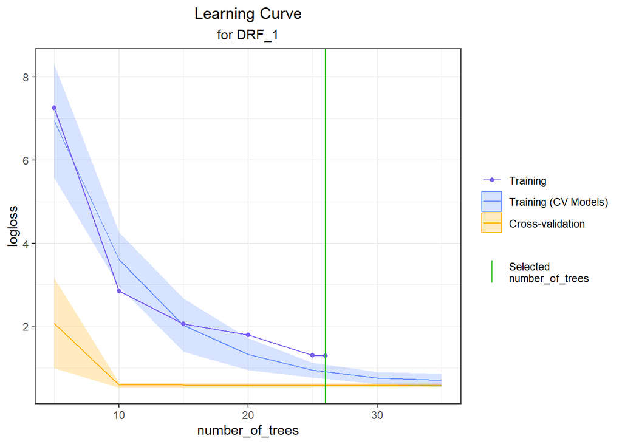

```
##
##
## Variable Importance
## ===================
##
## > The variable importance plot shows the relative importance of the most important variables in the model.
```

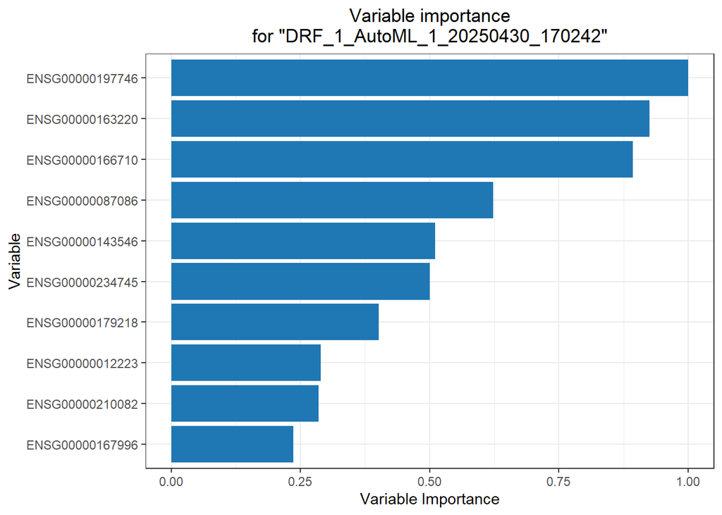

```
##
##
## SHAP Summary
## ============
##
## > SHAP summary plot shows the contribution of the features for each instance (row of data). The sum of the feature contributions and the bias term is equal to the raw prediction of the model, i.e., prediction before applying inverse link function.
```

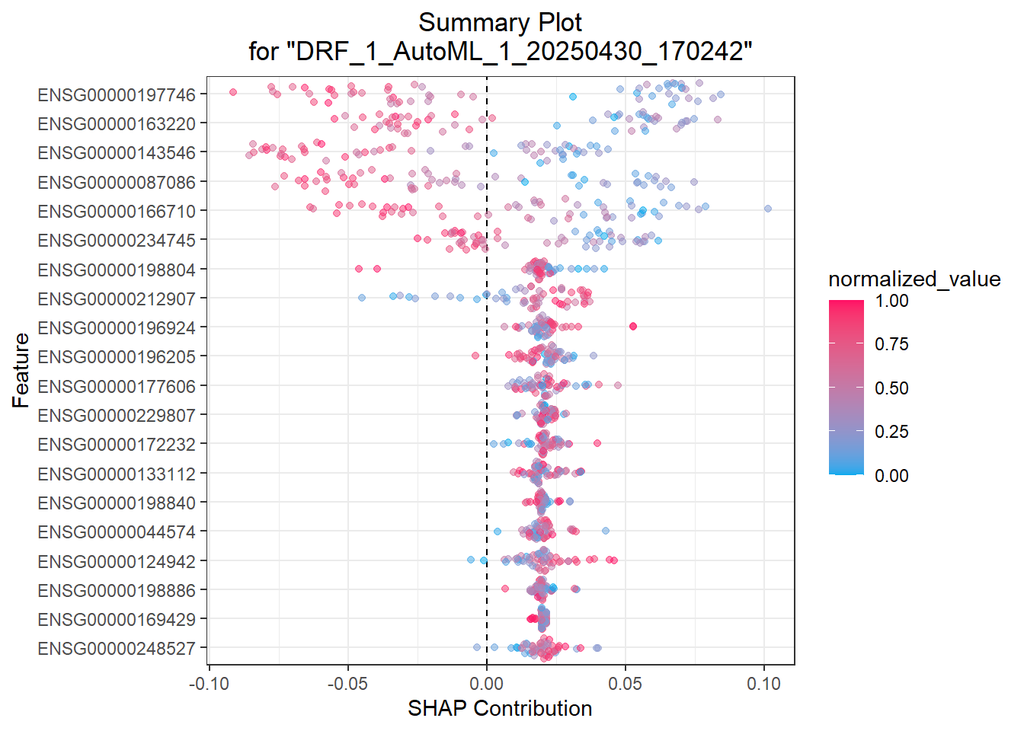

```
##
##
## Partial Dependence Plots
## ========================
##
## > Partial dependence plot (PDP) gives a graphical depiction of the marginal effect of a variable on the response. The effect of a variable is measured in change in the mean response. PDP assumes independence between the feature for which is the PDP computed and the rest.
```

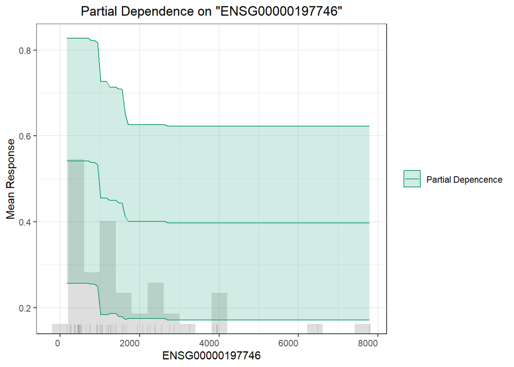

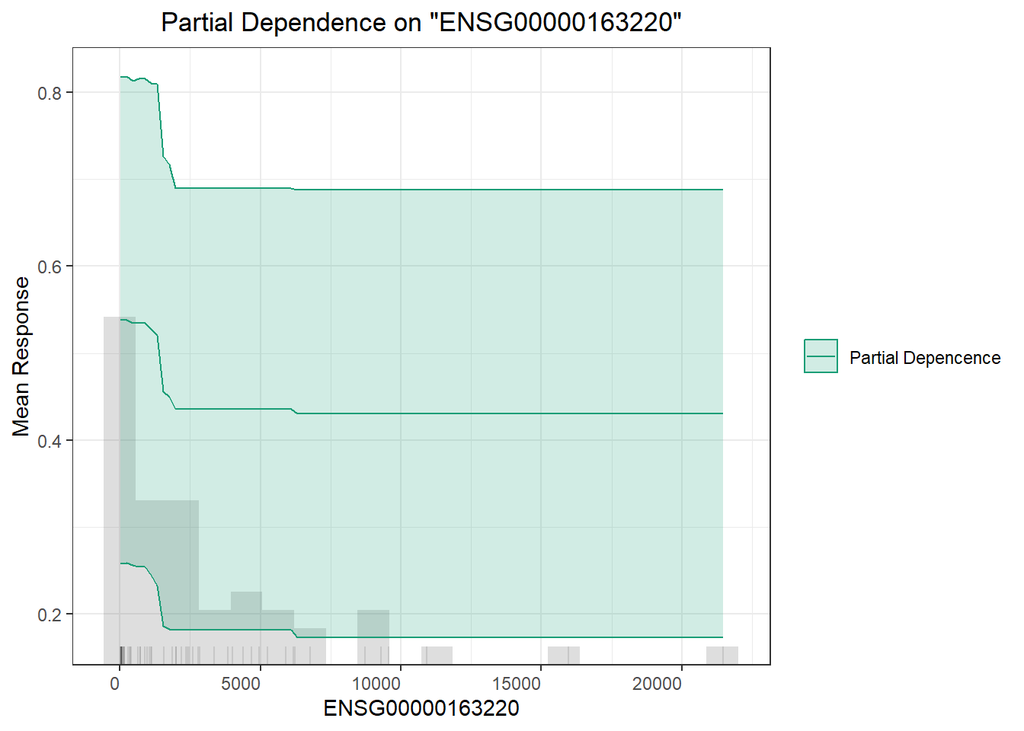

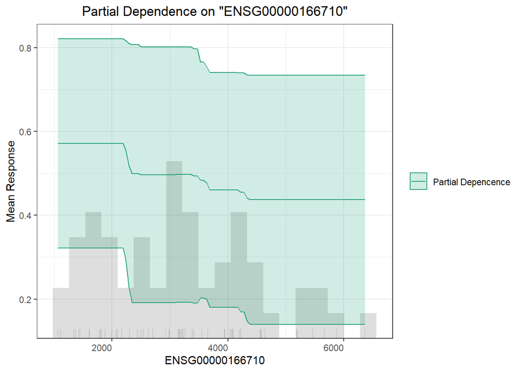

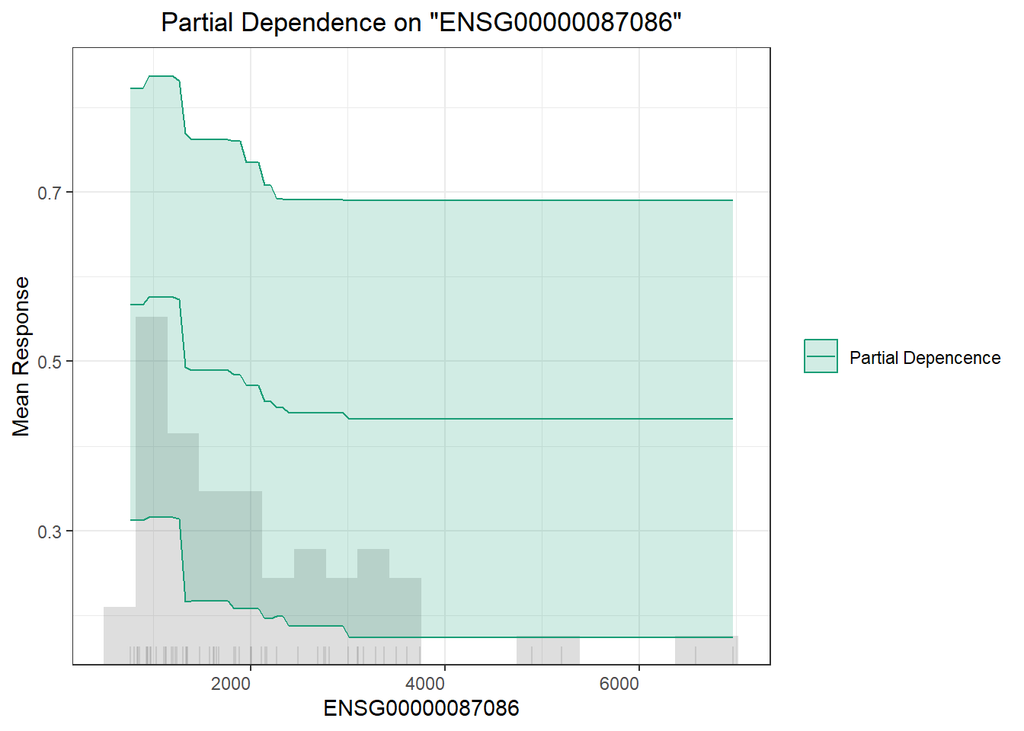

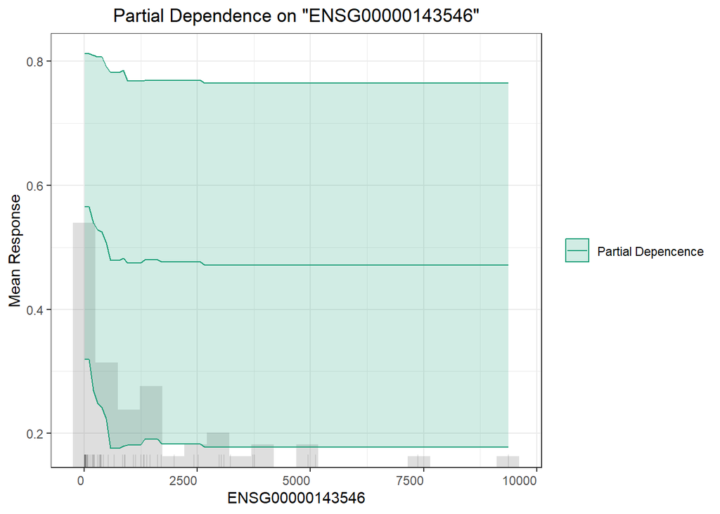

# Conclusion

In this tutorial, we explored how to:

- Prepare transcriptomic and drug response data
- Train and evaluate classification models using `caret`
- Compare models using cross-validation
- Explore AutoML capabilities with `h2o`

Participants are encouraged to experiment with:

- More drugs from the BeatAML dataset
- Additional pre-processing steps (e.g., PCA)
- Integration of mutation/variant data

Happy modeling!!